# Exploratory Juvenile Snowshoe Hare Report

Caroline Shepherd

11/6/2021

## Introduction

The data in this report comes from the Bonanza Creek Experimental Forest and uses data from 1999 - 2012 on snowshoe hare, *Lepus americanus*, populations. This report explores the relationship between juvenile snowshoe hares and their weight, sex, hindfoot length, and amount of hares per year. Snowshoe hares experience fluctuations in population every 8 to 11 years. This study aimed to collect data on snowshoe hares at the juvenile and adult stages, and with a variety of body measurements including body weight (g) and hindfoot length (mm).

## Data and Analyses

This code wrangles, visualizes, and summarizes snowshoe hare data from the Bonanza Creek Experiments conducted in Alaska from 1999 to 2012. This data was collected by Knut Kielland et al., and available from the EDI Data Portal. Individual counts of juvenile snowshoe hares are depicted, and summary statistics are explored for the weight of juveniles hares, grouped by sex. The relationship between hindfoot length (mm), body weight (g), and sex is also explored in this code.

Data source: Kielland, K., F.S. Chapin, R.W. Ruess, and Bonanza Creek LTER. 2017. Snowshoe hare physical data in Bonanza Creek Experimental Forest: 1999-Present ver 22. Environmental Data Initiative. https://doi.org/10.6073/pasta/03dce4856d79b91557d8e6ce2cbcdc14

## Initial Juvenile Hare Investigation

**Table 1.0** Descriptive statistics (mean, median, standard deviation, sample size, maximum, and minimum) for juvenile snowshoe hare trapping counts

| Mean Count | Median Count | Standard Deviation | Sample Size of Count | Maximum Count | Minimum Count |
| --- | --- | --- | --- | --- | --- |
| 31.5 | 18.5 | 35.88 | 12 | 126 | 2 |

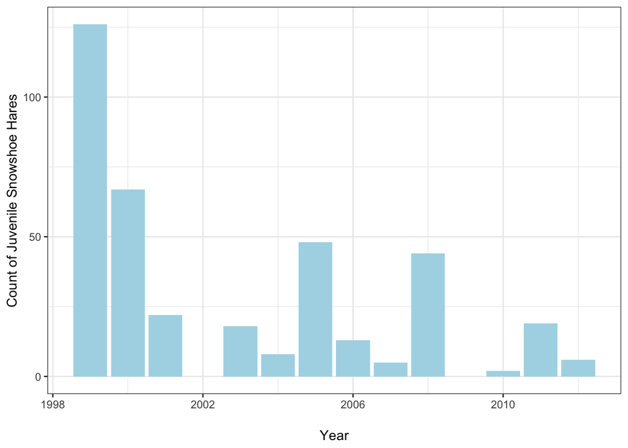

**Figure 1.0** Annual amount of juvenile snowshoe hares recorded

The average amount of hares has decreased from the year 1999 to 2012. We can see that the maximum amount of juvenile hares in a year (126) were recorded in 1999, the first year of the study. The minimum amount of hares found was 2in 2010, not including the years with zero hares recorded. The data shows a general downward trend in snowshoe hare counts.

This data represents the amount of juvenile hares recorded, not the absolute amount of juvenile hares. In most scientific sampling, especially of wild animals, the recorded number may not be the definitive amount of animals that exists. Moving forward, I suggest continuing sampling, while keeping as many variables the same as possible. For example, the sampling events should occur in the same places, and with the same protocol. More data will allow us to further analyze the population trends in snowshoe hares.

### Juvenile snowshoe hare weight (g) comparison

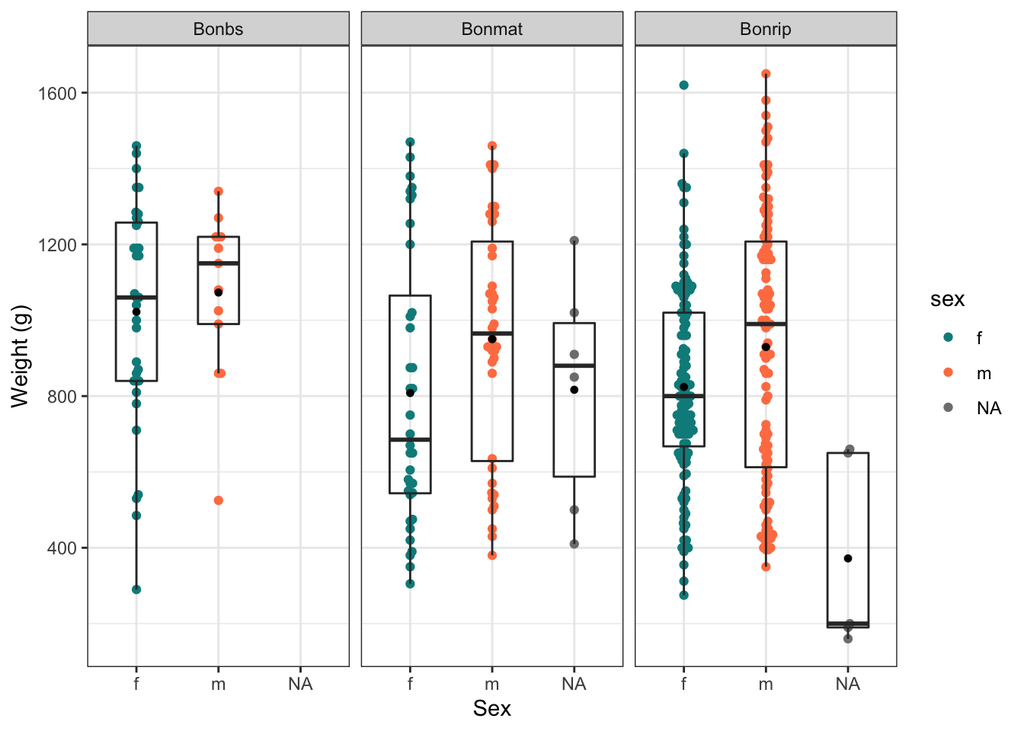

**Figure 2.0** Weight (g) observations for juvenile snowshoe hares at three different sampling locations (Bonbs, Bonmat, and Bonrip). The teal points represent female juvenile hare observations and the coral points represent male juvenile hare observations. The box endpoints represent the 25<sup>th</sup> and 75<sup>th</sup> percentile values, while the black line represents median value and the black dot indicates the mean value for each species, sorted by sex.

### Juvenile Weight Comparison Continued

Juvenile Hare Weight (g) Comparison

| Sex | Mean Weight (g) | Median Weight (g) | Standard Deviation (g) | Sample Size |
| --- | --- | --- | --- | --- |
| f | 855.39 | 825 | 292.25 | 200 |
| m | 945.86 | 990 | 333.22 | 163 |
| NA | 614.55 | 650 | 357.59 | 15 |

### Relationship between juvenile hare weight (g) and hind foot length (mm)

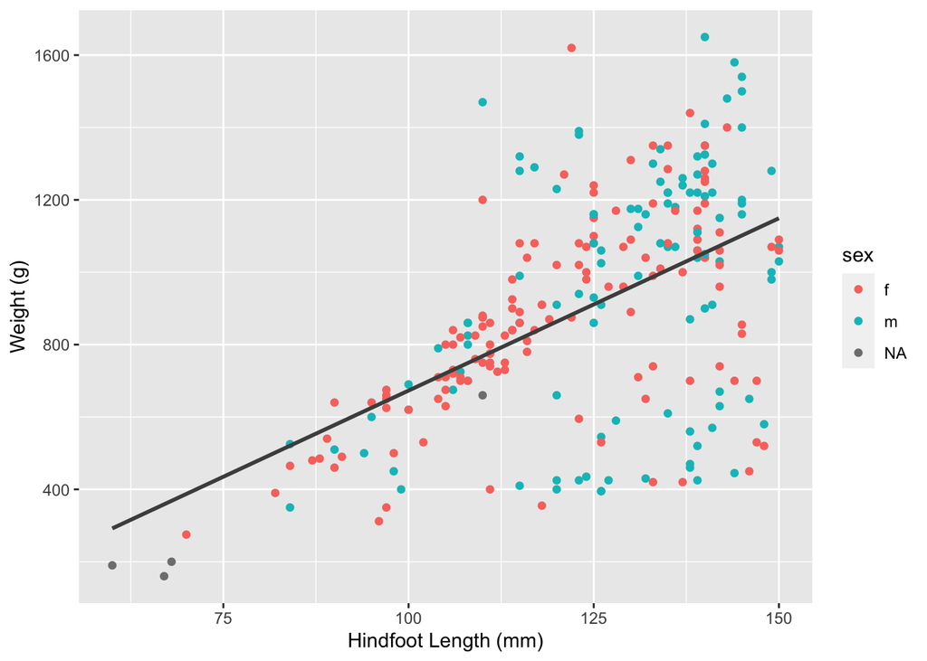

**Figure 3.** Relationship between hindfoot length (mm) and weight (g) for juvenile hares. Points indicate individual hare measurements (female hare measurement = coral pink; male hare measurements = teal green).